# **Analyzing Road Usage**

# **Analysis**

For the analysis, I start by creating a pairs plot for all the variables except for code route that has too many levels.

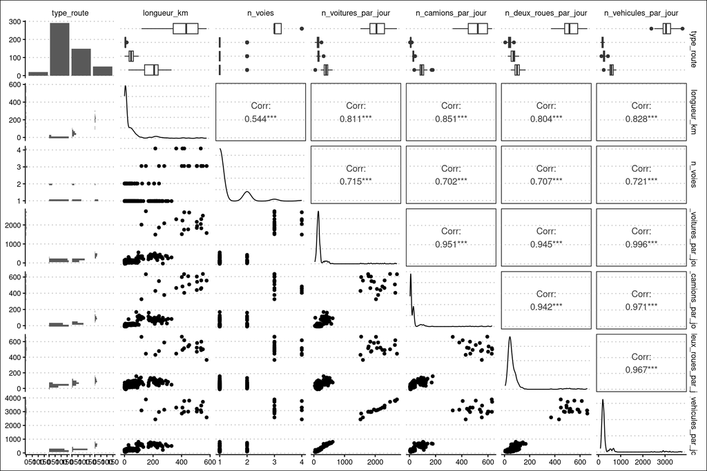

Pairs Plot for the Variables

Figure 1 shows strong correlation between the variables. This observation means that, for example, when there are more cars in the route, it is also highly probable that there will be more trucks. We now delve into our questions.

## What can be said about the distribution of road length?

I use a histogram to visualise road length. A histogram (together with density plots) are useful for visualizing the distribution of a single quantitative variable. Figure 2 shows that most roads are less than 100 km long, with another small up tick around 200 kilometres.

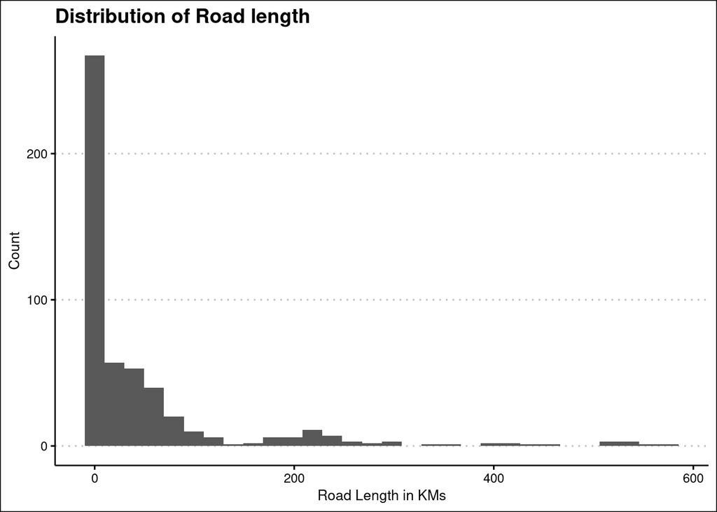

Distribution of Road length

```r
roads %>%
  ggplot(mapping = aes(x = longueur_km)) +
  geom_histogram() +
  labs(x = "Road Length in KMs", y = "Count", title = "Distribution of Road length")
```

I also slice the length of roads into chunks of 10km. The output shows that there are 270 roads that are at most 10 km further illustrating the skewness of the variable.

```r
cut(roads$longueur_km, breaks = seq(from = min(roads$longueur_km),
                                    to = max(roads$longueur_km),by = 10)) %>%
  table()
```

```
## .
##    (0,10]   (10,20]   (20,30]   (30,40]   (40,50]   (50,60]   (60,70]   (70,80]
##       270        34        19        29        26        21        18        12
##   (80,90]  (90,100] (100,110] (110,120] (120,130] (130,140] (140,150] (150,160]
##         8         8         2         4         1         1         1         0
## (160,170] (170,180] (180,190] (190,200] (200,210] (210,220] (220,230] (230,240]
##         3         2         2         2         5         4         7         1
## (240,250] (250,260] (260,270] (270,280] (280,290] (290,300] (300,310] (310,320]
##         5         1         3         1         1         1         1         0
## (320,330] (330,340] (340,350] (350,360] (360,370] (370,380] (380,390] (390,400]
##         1         0         0         0         1         0         0         0
## (400,410] (410,420] (420,430] (430,440] (440,450] (450,460] (460,470] (470,480]
##         2         2         0         0         1         1         0         0
## (480,490] (490,500] (500,510] (510,520] (520,530] (530,540] (540,550] (550,560]
##         0         0         3         0         0         3         1         0
## (560,570]
##         0
```

## What is the distribution of departmental roads?

Again, I use a histogram to visualise the distribution of departmental roads. Figure 4 shows that departmental roads are more evenly distributed with peaks between 25 kms to 50 kms. This distribution is closer to the normal distribution unlike the distribution of all roads that is heavily skewed to the right.

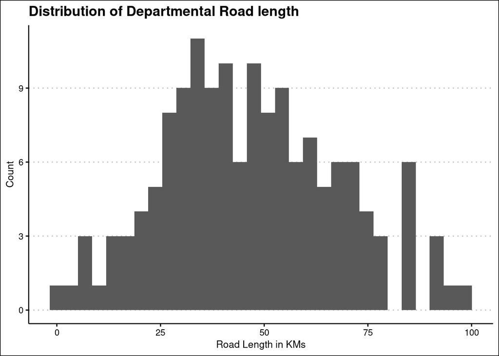

Distribution of Road length for Departmental Roads

```r
roads %>%
  filter(type_route == "departementale") %>%
  ggplot(mapping = aes(x = longueur_km)) +
  geom_histogram() +
  labs(x = "Road Length in KMs", y = "Count", title = "Distribution of Departmental Road length")
```

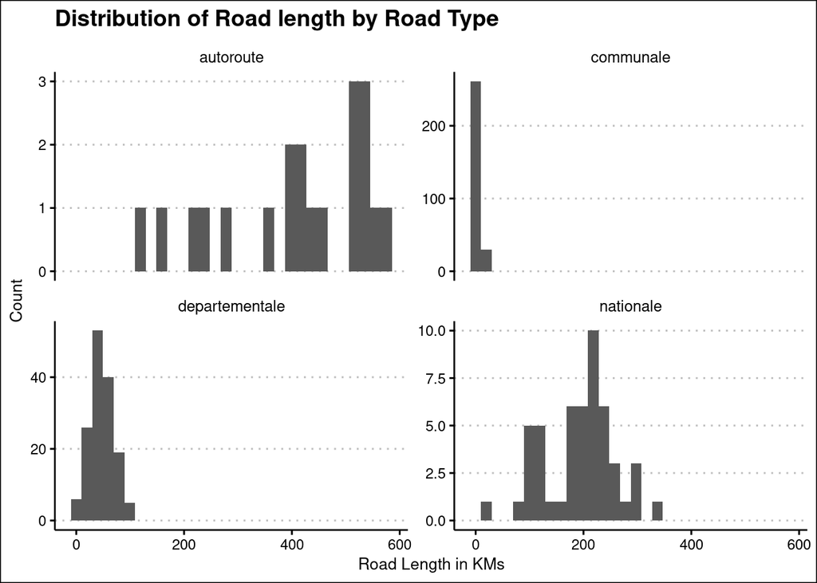

Distribution of Road length by Road Type

```r
roads %>%
  ggplot(mapping = aes(x = longueur_km)) +
  geom_histogram() +
  labs(x = "Road Length in KMs", y = "Count", title = "Distribution of Road length by Road Type") +
  facet_wrap(~ factor(type_route), scales = "free_y")
```

## To what extent does the number of vehicles using a road depend on the length of that road?

In this case, I test whether the relationship between the two variables is significant. I start by visualizing the two variables using a scatter plot because we have two quantitative variables. The scatter plot shows a general upward trend in the number of vehicles as the length of the roads increases (see Figure 6).

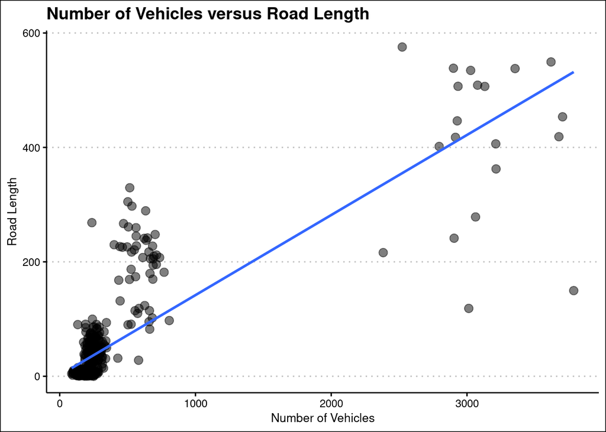

Number of Vehicles versus Road Length

```r
roads %>%
  ggplot(mapping = aes(x = n_vehicules_par_jour, y = longueur_km)) +
  geom_point(alpha = 0.5, size = 3) +
  geom_smooth(se = FALSE, method = "lm") + scale_color_tableau() +
  labs(title = "Number of Vehicles versus Road Length",
       x = "Number of Vehicles", y = "Road Length")
```

I also do a correlation test for the significance of the correlation between the length of the road (longueur_km) and the number of vehicles (n_vehicules_par_jour). This hypothesis is useful when dealing with two quantitative variables that have an approximate linear relationship as is the case here.

```r
with(roads, (cor.test(n_vehicules_par_jour, longueur_km)))
```

```
##
##  Pearson's product-moment correlation
##
## data:  n_vehicules_par_jour and longueur_km
## t = 33, df = 508, p-value <2e-16
## alternative hypothesis: true correlation is not equal to 0
## 95 percent confidence interval:
##  0.80 0.85
## sample estimates:
##  cor
## 0.83
```

The output shows that we reject the null hypothesis of no relationship between the road (longueur_km) and the number of vehicles (n_vehicules_par_jour) at 1% level of significance.

## Is this ratio the same for the different road types?

The extent of this relationship depends on the road type, with auto-route and departmental roads showing little correlation between road length and number of vehicles. Communal and national roads show a negative correlation between the length of the road and the number of vehicles. National roads have the highest negative correlation between road length and number of vehicles (see Figure 7).

```r
roads %>%
  summarise(

    correlation = cor(n_vehicules_par_jour, longueur_km),

    .by = type_route
  ) %>%

  arrange(desc(correlation))
```

```
##       type_route correlation
## 1 departementale      0.0128
## 2      autoroute      0.0035
## 3      communale     -0.0284
## 4      nationale     -0.2360
```

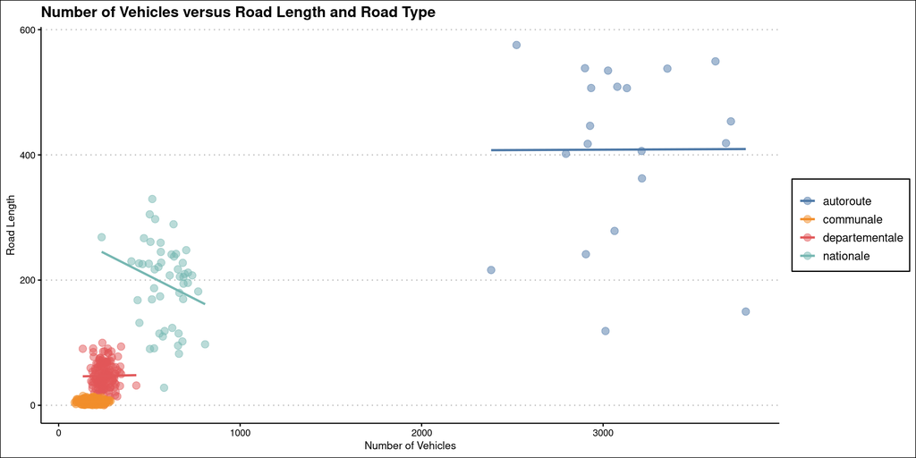

Number of Vehicles versus Road Length and Road Type

```r
roads %>%
  ggplot(mapping = aes(x = n_vehicules_par_jour, y = longueur_km, color = type_route)) +
  geom_point(alpha = 0.5, size = 3) + geom_smooth(se = FALSE, method = "lm") + scale_color_tableau() +
  labs(title = "Number of Vehicles versus Road Length and Road Type",
        x = "Number of Vehicles", y = "Road Length") + theme(legend.title = element_blank())
```

## Are departmental roads shorter on average than national roads?

```r
roads %>%
  filter(type_route %in% c("departementale", "nationale")) %>%
  summarise(

    Mean_length = mean(longueur_km),
    Median_length = median(longueur_km),
    .by = type_route
  ) %>%

  set_names(names(.) %>% str_to_title()) %>%

  mutate(Type_route = str_to_title(Type_route)) %>%

  kbl(booktabs = TRUE, caption = "Road Lengths for National/Departmental Roads") %>%
  kable_classic(full_width = TRUE, latex_options = "hold_position")
```

Road Lengths for National/Departmental Roads

| Type_route | Mean_length | Median_length |
| --- | --- | --- |
| Nationale | 193 | 208 |
| Departementale | 47 | 46 |

I also carry out a t-test to examine whether the observed difference is statistically significant. We reject the null hypothesis at 1% significance level which means that there is a significant relationship between road type (national versus departmental) and the length of the road.

```r
roads %>%
  filter(type_route %in% c("departementale", "nationale")) %>%
  mutate(type_route = factor(type_route, levels = c("departementale", "nationale"))) %>%
t.test(longueur_km ~ type_route, data = .)
```

```
##
##  Welch Two Sample t-test
##
## data:  longueur_km by type_route
## t = -15, df = 52, p-value <2e-16
## alternative hypothesis: true difference in means between group departementale and group nationale is not equal to 0
## 95 percent confidence interval:
##  -166 -127
## sample estimates:
## mean in group departementale      mean in group nationale
##                           47                          193
```

## Is there a difference in length depending on the number of lanes?

```r
roads %>%
  mutate(n_voies = factor(n_voies)) %>%
  summarise(

    Mean_length = mean(longueur_km),
    Median_length = median(longueur_km),
    .by = n_voies
  ) %>%

  set_names(names(.) %>% str_to_title()) %>%

  mutate(N_voies = str_to_title(N_voies)) %>%

  kbl(booktabs = TRUE, caption = "Mean and Median Road Lengths by Number of lanes") %>%
  kable_classic(full_width = TRUE, latex_options = "hold_position")
```

Mean and Median Road Lengths by Number of lanes

| N_voies | Mean_length | Median_length |
| --- | --- | --- |
| 3 | 415 | 453.5 |
| 4 | 388 | 406.2 |
| 2 | 36 | 10.5 |
| 1 | 38 | 8.7 |

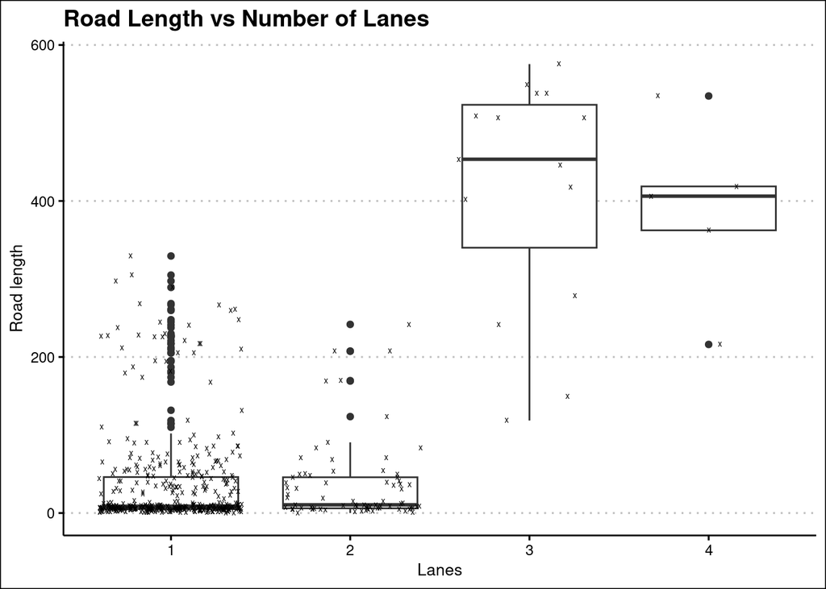

Road Length vs Number of Lanes

```r
roads %>%
  ggplot(mapping = aes(y = longueur_km, x = factor(n_voies))) +
  geom_boxplot() + geom_jitter(shape = 'x') + scale_fill_tableau() +
  labs(title = "Road Length vs Number of Lanes", x = "Lanes", y = "Road length")
```

## Which road types are dominated by trucks?

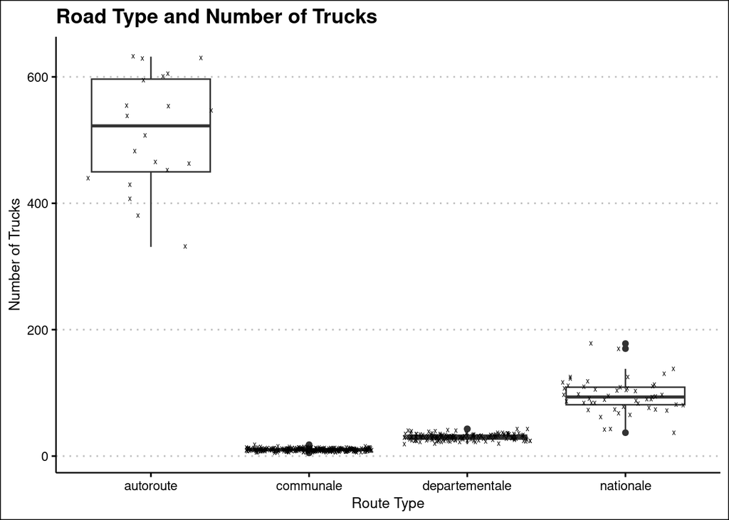

```r
roads %>%
  ggplot(mapping = aes(x = type_route, y = n_camions_par_jour)) +
  geom_boxplot() + geom_jitter(shape = "x") +
  labs(x = "Route Type", y = "Number of Trucks", title = "Road Type and Number of Trucks")
```

# **Conclusion**

The analysis would be useful for traffic management.